# Risk Factor Analysis

## Outcome Variable

**Outcome Variable:** pers_wast

## Predictor Variables

**Intervention Variable:** fage

**Adjustment Set:**

- arm
- W_mage
- meducyrs
- feducyrs
- W_mhtcm
- W_mwtkg
- W_mbmi
- W_fhtcm
- single
- brthmon
- delta_W_mage
- delta_meducyrs
- delta_feducyrs
- delta_W_mhtcm
- delta_W_mwtkg
- delta_W_mbmi
- delta_W_fhtcm
- delta_single
- delta_brthmon

## Stratifying Variables

The analysis was stratified on these variable(s):

- agecat
- studyid
- country

## Data Summary

| agecat | studyid | country | fage | pers_wast | n_cell | n |
| --- | --- | --- | --- | --- | --- | --- |
| 0-24 months | ki0047075b-MAL-ED | BANGLADESH | >=38 | 0 | 65 | 151 |
| 0-24 months | ki0047075b-MAL-ED | BANGLADESH | >=38 | 1 | 4 | 151 |
| 0-24 months | ki0047075b-MAL-ED | BANGLADESH | <32 | 0 | 30 | 151 |
| 0-24 months | ki0047075b-MAL-ED | BANGLADESH | <32 | 1 | 0 | 151 |
| 0-24 months | ki0047075b-MAL-ED | BANGLADESH | [32-38) | 0 | 49 | 151 |
| 0-24 months | ki0047075b-MAL-ED | BANGLADESH | [32-38) | 1 | 3 | 151 |
| 0-24 months | ki0047075b-MAL-ED | BRAZIL | >=38 | 0 | 30 | 79 |
| 0-24 months | ki0047075b-MAL-ED | BRAZIL | >=38 | 1 | 0 | 79 |
| 0-24 months | ki0047075b-MAL-ED | BRAZIL | <32 | 0 | 18 | 79 |
| 0-24 months | ki0047075b-MAL-ED | BRAZIL | <32 | 1 | 0 | 79 |
| 0-24 months | ki0047075b-MAL-ED | BRAZIL | [32-38) | 0 | 30 | 79 |
| 0-24 months | ki0047075b-MAL-ED | BRAZIL | [32-38) | 1 | 1 | 79 |
| 0-24 months | ki0047075b-MAL-ED | INDIA | >=38 | 0 | 36 | 161 |
| 0-24 months | ki0047075b-MAL-ED | INDIA | >=38 | 1 | 0 | 161 |
| 0-24 months | ki0047075b-MAL-ED | INDIA | <32 | 0 | 46 | 161 |
| 0-24 months | ki0047075b-MAL-ED | INDIA | <32 | 1 | 7 | 161 |
| 0-24 months | ki0047075b-MAL-ED | INDIA | [32-38) | 0 | 66 | 161 |
| 0-24 months | ki0047075b-MAL-ED | INDIA | [32-38) | 1 | 6 | 161 |
| 0-24 months | ki0047075b-MAL-ED | NEPAL | >=38 | 0 | 17 | 79 |
| 0-24 months | ki0047075b-MAL-ED | NEPAL | >=38 | 1 | 0 | 79 |
| 0-24 months | ki0047075b-MAL-ED | NEPAL | <32 | 0 | 14 | 79 |
| 0-24 months | ki0047075b-MAL-ED | NEPAL | <32 | 1 | 1 | 79 |
| 0-24 months | ki0047075b-MAL-ED | NEPAL | [32-38) | 0 | 47 | 79 |
| 0-24 months | ki0047075b-MAL-ED | NEPAL | [32-38) | 1 | 0 | 79 |
| 0-24 months | ki0047075b-MAL-ED | PERU | >=38 | 0 | 27 | 84 |
| 0-24 months | ki0047075b-MAL-ED | PERU | >=38 | 1 | 0 | 84 |
| 0-24 months | ki0047075b-MAL-ED | PERU | <32 | 0 | 28 | 84 |
| 0-24 months | ki0047075b-MAL-ED | PERU | <32 | 1 | 1 | 84 |
| 0-24 months | ki0047075b-MAL-ED | PERU | [32-38) | 0 | 28 | 84 |
| 0-24 months | ki0047075b-MAL-ED | PERU | [32-38) | 1 | 0 | 84 |

[output cut: 168 more lines]

The following strata were considered:

- agecat: 0-24 months, studyid: ki0047075b-MAL-ED, country: BANGLADESH
- agecat: 0-24 months, studyid: ki0047075b-MAL-ED, country: BRAZIL
- agecat: 0-24 months, studyid: ki0047075b-MAL-ED, country: INDIA
- agecat: 0-24 months, studyid: ki0047075b-MAL-ED, country: NEPAL
- agecat: 0-24 months, studyid: ki0047075b-MAL-ED, country: PERU
- agecat: 0-24 months, studyid: ki0047075b-MAL-ED, country: SOUTH AFRICA
- agecat: 0-24 months, studyid: ki0047075b-MAL-ED, country: TANZANIA, UNITED REPUBLIC OF
- agecat: 0-24 months, studyid: ki1000304b-SAS-CompFeed, country: INDIA
- agecat: 0-24 months, studyid: ki1000304b-SAS-FoodSuppl, country: INDIA
- agecat: 0-24 months, studyid: ki1119695-PROBIT, country: BELARUS
- agecat: 0-24 months, studyid: ki1135781-COHORTS, country: GUATEMALA
- agecat: 0-24 months, studyid: ki1135781-COHORTS, country: PHILIPPINES
- agecat: 0-24 months, studyid: ki1148112-LCNI-5, country: MALAWI
- agecat: 0-6 months, studyid: ki0047075b-MAL-ED, country: BANGLADESH
- agecat: 0-6 months, studyid: ki0047075b-MAL-ED, country: BRAZIL
- agecat: 0-6 months, studyid: ki0047075b-MAL-ED, country: INDIA
- agecat: 0-6 months, studyid: ki0047075b-MAL-ED, country: NEPAL
- agecat: 0-6 months, studyid: ki0047075b-MAL-ED, country: PERU
- agecat: 0-6 months, studyid: ki0047075b-MAL-ED, country: SOUTH AFRICA
- agecat: 0-6 months, studyid: ki0047075b-MAL-ED, country: TANZANIA, UNITED REPUBLIC OF
- agecat: 6-24 months, studyid: ki0047075b-MAL-ED, country: BANGLADESH
- agecat: 6-24 months, studyid: ki0047075b-MAL-ED, country: BRAZIL
- agecat: 6-24 months, studyid: ki0047075b-MAL-ED, country: INDIA
- agecat: 6-24 months, studyid: ki0047075b-MAL-ED, country: NEPAL
- agecat: 6-24 months, studyid: ki0047075b-MAL-ED, country: PERU
- agecat: 6-24 months, studyid: ki0047075b-MAL-ED, country: SOUTH AFRICA
- agecat: 6-24 months, studyid: ki0047075b-MAL-ED, country: TANZANIA, UNITED REPUBLIC OF
- agecat: 6-24 months, studyid: ki1000304b-SAS-CompFeed, country: INDIA
- agecat: 6-24 months, studyid: ki1000304b-SAS-FoodSuppl, country: INDIA
- agecat: 6-24 months, studyid: ki1119695-PROBIT, country: BELARUS
- agecat: 6-24 months, studyid: ki1135781-COHORTS, country: GUATEMALA
- agecat: 6-24 months, studyid: ki1135781-COHORTS, country: PHILIPPINES
- agecat: 6-24 months, studyid: ki1148112-LCNI-5, country: MALAWI

### Dropped Strata

Some strata were dropped due to rare outcomes:

- agecat: 0-24 months, studyid: ki0047075b-MAL-ED, country: BANGLADESH
- agecat: 0-24 months, studyid: ki0047075b-MAL-ED, country: BRAZIL
- agecat: 0-24 months, studyid: ki0047075b-MAL-ED, country: INDIA
- agecat: 0-24 months, studyid: ki0047075b-MAL-ED, country: NEPAL
- agecat: 0-24 months, studyid: ki0047075b-MAL-ED, country: PERU
- agecat: 0-24 months, studyid: ki0047075b-MAL-ED, country: SOUTH AFRICA
- agecat: 0-24 months, studyid: ki0047075b-MAL-ED, country: TANZANIA, UNITED REPUBLIC OF
- agecat: 0-24 months, studyid: ki1148112-LCNI-5, country: MALAWI
- agecat: 0-6 months, studyid: ki0047075b-MAL-ED, country: BANGLADESH
- agecat: 0-6 months, studyid: ki0047075b-MAL-ED, country: BRAZIL
- agecat: 0-6 months, studyid: ki0047075b-MAL-ED, country: INDIA
- agecat: 0-6 months, studyid: ki0047075b-MAL-ED, country: NEPAL
- agecat: 0-6 months, studyid: ki0047075b-MAL-ED, country: PERU
- agecat: 0-6 months, studyid: ki0047075b-MAL-ED, country: SOUTH AFRICA
- agecat: 0-6 months, studyid: ki0047075b-MAL-ED, country: TANZANIA, UNITED REPUBLIC OF
- agecat: 6-24 months, studyid: ki0047075b-MAL-ED, country: BANGLADESH
- agecat: 6-24 months, studyid: ki0047075b-MAL-ED, country: BRAZIL
- agecat: 6-24 months, studyid: ki0047075b-MAL-ED, country: INDIA
- agecat: 6-24 months, studyid: ki0047075b-MAL-ED, country: NEPAL
- agecat: 6-24 months, studyid: ki0047075b-MAL-ED, country: PERU
- agecat: 6-24 months, studyid: ki0047075b-MAL-ED, country: SOUTH AFRICA
- agecat: 6-24 months, studyid: ki0047075b-MAL-ED, country: TANZANIA, UNITED REPUBLIC OF
- agecat: 6-24 months, studyid: ki1119695-PROBIT, country: BELARUS
- agecat: 6-24 months, studyid: ki1148112-LCNI-5, country: MALAWI

## Methods Detail

We’re interested in the causal parameters $E[Y_a]$ for all values of $a \in \mathcal{A}$. These parameters represent the mean outcome if, possibly contrary to fact, we intervened to set all units to have $A=a$. Under the randomization and positivity assumptions, these are identified by the statistical parameters $\psi_a=E_W[E_{Y|A,W}(Y|A=a,W)]$. In addition, we’re interested in the mean of $Y$, $E[Y]$ under no intervention (the observed mean). We will estimate these parameters by using SuperLearner to fit the relevant likelihood factors – $E_{Y|A,W}(Y|A=a,W)$ and $p(A=a|W)$, and then updating our likelihood fit using a joint TMLE.

For unadjusted analyses ($W=\{\}$), initial likelihoods were estimated using Lrnr_glm to estimate the simple $E(Y|A)$ and Lrnr_mean to estimate $p(A)$. For adjusted analyses, a small library containing Lrnr_glmnet, Lrnr_xgboost, and Lrnr_mean was used.

Having estimated these parameters, we will then use the delta method to estimate relative risks and attributable risks relative to a prespecified baseline level of $A$.

# Results Detail

## Results Plots

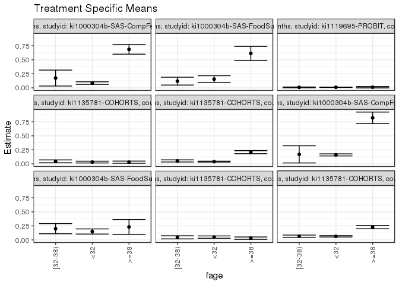

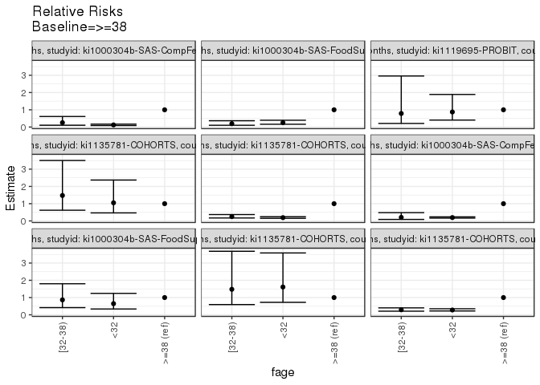

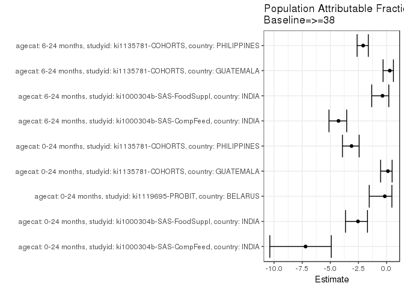

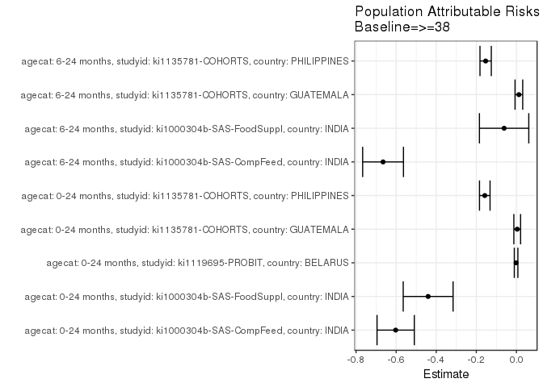

## Results Table

### Parameter: TSM

| agecat | studyid | country | intervention_level | baseline_level | estimate | ci_lower | ci_upper |
| --- | --- | --- | --- | --- | --- | --- | --- |
| 0-24 months | ki1000304b-SAS-CompFeed | INDIA | >=38 | NA | 0.6859416 | 0.6003636 | 0.7715196 |
| 0-24 months | ki1000304b-SAS-CompFeed | INDIA | <32 | NA | 0.0844946 | 0.0614929 | 0.1074963 |
| 0-24 months | ki1000304b-SAS-CompFeed | INDIA | [32-38) | NA | 0.1743117 | 0.0320007 | 0.3166227 |
| 0-24 months | ki1000304b-SAS-FoodSuppl | INDIA | >=38 | NA | 0.6135770 | 0.4881123 | 0.7390418 |
| 0-24 months | ki1000304b-SAS-FoodSuppl | INDIA | <32 | NA | 0.1556063 | 0.0950447 | 0.2161678 |
| 0-24 months | ki1000304b-SAS-FoodSuppl | INDIA | [32-38) | NA | 0.1194939 | 0.0493019 | 0.1896859 |
| 0-24 months | ki1119695-PROBIT | BELARUS | >=38 | NA | 0.0109141 | -0.0006952 | 0.0225233 |
| 0-24 months | ki1119695-PROBIT | BELARUS | <32 | NA | 0.0095335 | 0.0052504 | 0.0138166 |
| 0-24 months | ki1119695-PROBIT | BELARUS | [32-38) | NA | 0.0085890 | 0.0019106 | 0.0152673 |
| 0-24 months | ki1135781-COHORTS | GUATEMALA | >=38 | NA | 0.0302013 | 0.0107608 | 0.0496418 |
| 0-24 months | ki1135781-COHORTS | GUATEMALA | <32 | NA | 0.0317125 | 0.0159128 | 0.0475121 |
| 0-24 months | ki1135781-COHORTS | GUATEMALA | [32-38) | NA | 0.0445344 | 0.0187968 | 0.0702720 |
| 0-24 months | ki1135781-COHORTS | PHILIPPINES | >=38 | NA | 0.2084115 | 0.1811195 | 0.2357034 |
| 0-24 months | ki1135781-COHORTS | PHILIPPINES | <32 | NA | 0.0399563 | 0.0318106 | 0.0481019 |
| 0-24 months | ki1135781-COHORTS | PHILIPPINES | [32-38) | NA | 0.0523747 | 0.0332633 | 0.0714860 |
| 6-24 months | ki1000304b-SAS-CompFeed | INDIA | >=38 | NA | 0.8209316 | 0.7178526 | 0.9240105 |
| 6-24 months | ki1000304b-SAS-CompFeed | INDIA | <32 | NA | 0.1601751 | 0.1414625 | 0.1788877 |
| 6-24 months | ki1000304b-SAS-CompFeed | INDIA | [32-38) | NA | 0.1693330 | 0.0159667 | 0.3226994 |
| 6-24 months | ki1000304b-SAS-FoodSuppl | INDIA | >=38 | NA | 0.2307692 | 0.0983479 | 0.3631906 |
| 6-24 months | ki1000304b-SAS-FoodSuppl | INDIA | <32 | NA | 0.1495726 | 0.1038101 | 0.1953352 |
| 6-24 months | ki1000304b-SAS-FoodSuppl | INDIA | [32-38) | NA | 0.2000000 | 0.1093428 | 0.2906572 |
| 6-24 months | ki1135781-COHORTS | GUATEMALA | >=38 | NA | 0.0308880 | 0.0098056 | 0.0519705 |
| 6-24 months | ki1135781-COHORTS | GUATEMALA | <32 | NA | 0.0497630 | 0.0290042 | 0.0705219 |
| 6-24 months | ki1135781-COHORTS | GUATEMALA | [32-38) | NA | 0.0456621 | 0.0179993 | 0.0733249 |
| 6-24 months | ki1135781-COHORTS | PHILIPPINES | >=38 | NA | 0.2271613 | 0.1979414 | 0.2563812 |
| 6-24 months | ki1135781-COHORTS | PHILIPPINES | <32 | NA | 0.0634597 | 0.0517217 | 0.0751976 |
| 6-24 months | ki1135781-COHORTS | PHILIPPINES | [32-38) | NA | 0.0662992 | 0.0466081 | 0.0859902 |

### Parameter: E(Y)

| agecat | studyid | country | intervention_level | baseline_level | estimate | ci_lower | ci_upper |
| --- | --- | --- | --- | --- | --- | --- | --- |
| 0-24 months | ki1000304b-SAS-CompFeed | INDIA | NA | NA | 0.0836390 | 0.0602327 | 0.1070453 |
| 0-24 months | ki1000304b-SAS-FoodSuppl | INDIA | NA | NA | 0.1733333 | 0.1349698 | 0.2116969 |
| 0-24 months | ki1119695-PROBIT | BELARUS | NA | NA | 0.0094523 | 0.0051727 | 0.0137318 |
| 0-24 months | ki1135781-COHORTS | GUATEMALA | NA | NA | 0.0343811 | 0.0231829 | 0.0455794 |
| 0-24 months | ki1135781-COHORTS | PHILIPPINES | NA | NA | 0.0506794 | 0.0424394 | 0.0589194 |
| 6-24 months | ki1000304b-SAS-CompFeed | INDIA | NA | NA | 0.1557036 | 0.1398038 | 0.1716033 |
| 6-24 months | ki1000304b-SAS-FoodSuppl | INDIA | NA | NA | 0.1695402 | 0.1300601 | 0.2090204 |
| 6-24 months | ki1135781-COHORTS | GUATEMALA | NA | NA | 0.0433333 | 0.0300239 | 0.0566428 |
| 6-24 months | ki1135781-COHORTS | PHILIPPINES | NA | NA | 0.0737705 | 0.0636467 | 0.0838943 |

### Parameter: RR

| agecat | studyid | country | intervention_level | baseline_level | estimate | ci_lower | ci_upper |
| --- | --- | --- | --- | --- | --- | --- | --- |
| 0-24 months | ki1000304b-SAS-CompFeed | INDIA | >=38 | >=38 | 1.0000000 | 1.0000000 | 1.0000000 |
| 0-24 months | ki1000304b-SAS-CompFeed | INDIA | <32 | >=38 | 0.1231805 | 0.0896821 | 0.1691911 |
| 0-24 months | ki1000304b-SAS-CompFeed | INDIA | [32-38) | >=38 | 0.2541204 | 0.1053913 | 0.6127369 |
| 0-24 months | ki1000304b-SAS-FoodSuppl | INDIA | >=38 | >=38 | 1.0000000 | 1.0000000 | 1.0000000 |
| 0-24 months | ki1000304b-SAS-FoodSuppl | INDIA | <32 | >=38 | 0.2536051 | 0.1629479 | 0.3947001 |
| 0-24 months | ki1000304b-SAS-FoodSuppl | INDIA | [32-38) | >=38 | 0.1947496 | 0.1038290 | 0.3652871 |
| 0-24 months | ki1119695-PROBIT | BELARUS | >=38 | >=38 | 1.0000000 | 1.0000000 | 1.0000000 |
| 0-24 months | ki1119695-PROBIT | BELARUS | <32 | >=38 | 0.8735055 | 0.4040925 | 1.8882107 |
| 0-24 months | ki1119695-PROBIT | BELARUS | [32-38) | >=38 | 0.7869632 | 0.2094002 | 2.9575476 |
| 0-24 months | ki1135781-COHORTS | GUATEMALA | >=38 | >=38 | 1.0000000 | 1.0000000 | 1.0000000 |
| 0-24 months | ki1135781-COHORTS | GUATEMALA | <32 | >=38 | 1.0500352 | 0.4652609 | 2.3697973 |
| 0-24 months | ki1135781-COHORTS | GUATEMALA | [32-38) | >=38 | 1.4745839 | 0.6208331 | 3.5023869 |
| 0-24 months | ki1135781-COHORTS | PHILIPPINES | >=38 | >=38 | 1.0000000 | 1.0000000 | 1.0000000 |
| 0-24 months | ki1135781-COHORTS | PHILIPPINES | <32 | >=38 | 0.1917183 | 0.1505440 | 0.2441539 |
| 0-24 months | ki1135781-COHORTS | PHILIPPINES | [32-38) | >=38 | 0.2513041 | 0.1704981 | 0.3704074 |
| 6-24 months | ki1000304b-SAS-CompFeed | INDIA | >=38 | >=38 | 1.0000000 | 1.0000000 | 1.0000000 |
| 6-24 months | ki1000304b-SAS-CompFeed | INDIA | <32 | >=38 | 0.1951139 | 0.1622404 | 0.2346482 |
| 6-24 months | ki1000304b-SAS-CompFeed | INDIA | [32-38) | >=38 | 0.2062694 | 0.0885341 | 0.4805725 |
| 6-24 months | ki1000304b-SAS-FoodSuppl | INDIA | >=38 | >=38 | 1.0000000 | 1.0000000 | 1.0000000 |
| 6-24 months | ki1000304b-SAS-FoodSuppl | INDIA | <32 | >=38 | 0.6481481 | 0.3382630 | 1.2419214 |
| 6-24 months | ki1000304b-SAS-FoodSuppl | INDIA | [32-38) | >=38 | 0.8666667 | 0.4171277 | 1.8006744 |
| 6-24 months | ki1135781-COHORTS | GUATEMALA | >=38 | >=38 | 1.0000000 | 1.0000000 | 1.0000000 |
| 6-24 months | ki1135781-COHORTS | GUATEMALA | <32 | >=38 | 1.6110782 | 0.7239561 | 3.5852629 |
| 6-24 months | ki1135781-COHORTS | GUATEMALA | [32-38) | >=38 | 1.4783105 | 0.5934970 | 3.6822462 |
| 6-24 months | ki1135781-COHORTS | PHILIPPINES | >=38 | >=38 | 1.0000000 | 1.0000000 | 1.0000000 |
| 6-24 months | ki1135781-COHORTS | PHILIPPINES | <32 | >=38 | 0.2793594 | 0.2231235 | 0.3497690 |
| 6-24 months | ki1135781-COHORTS | PHILIPPINES | [32-38) | >=38 | 0.2918593 | 0.2110045 | 0.4036970 |

### Parameter: PAR

| agecat | studyid | country | intervention_level | baseline_level | estimate | ci_lower | ci_upper |
| --- | --- | --- | --- | --- | --- | --- | --- |
| 0-24 months | ki1000304b-SAS-CompFeed | INDIA | >=38 | NA | -0.6023026 | -0.6952352 | -0.5093699 |
| 0-24 months | ki1000304b-SAS-FoodSuppl | INDIA | >=38 | NA | -0.4402437 | -0.5646583 | -0.3158290 |
| 0-24 months | ki1119695-PROBIT | BELARUS | >=38 | NA | -0.0014618 | -0.0103666 | 0.0074430 |
| 0-24 months | ki1135781-COHORTS | GUATEMALA | >=38 | NA | 0.0041798 | -0.0126151 | 0.0209747 |
| 0-24 months | ki1135781-COHORTS | PHILIPPINES | >=38 | NA | -0.1577321 | -0.1840659 | -0.1313982 |
| 6-24 months | ki1000304b-SAS-CompFeed | INDIA | >=38 | NA | -0.6652280 | -0.7670440 | -0.5634120 |
| 6-24 months | ki1000304b-SAS-FoodSuppl | INDIA | >=38 | NA | -0.0612290 | -0.1843701 | 0.0619121 |
| 6-24 months | ki1135781-COHORTS | GUATEMALA | >=38 | NA | 0.0124453 | -0.0066804 | 0.0315711 |
| 6-24 months | ki1135781-COHORTS | PHILIPPINES | >=38 | NA | -0.1533908 | -0.1816338 | -0.1251479 |

### Parameter: PAF

| agecat | studyid | country | intervention_level | baseline_level | estimate | ci_lower | ci_upper |
| --- | --- | --- | --- | --- | --- | --- | --- |
| 0-24 months | ki1000304b-SAS-CompFeed | INDIA | >=38 | NA | -7.2012141 | -10.3784302 | -4.9111767 |
| 0-24 months | ki1000304b-SAS-FoodSuppl | INDIA | >=38 | NA | -2.5398674 | -3.6507254 | -1.6943455 |
| 0-24 months | ki1119695-PROBIT | BELARUS | >=38 | NA | -0.1546489 | -1.5393504 | 0.4749783 |
| 0-24 months | ki1135781-COHORTS | GUATEMALA | >=38 | NA | 0.1215724 | -0.5292244 | 0.4954076 |
| 0-24 months | ki1135781-COHORTS | PHILIPPINES | >=38 | NA | -3.1123507 | -3.9218903 | -2.4359620 |
| 6-24 months | ki1000304b-SAS-CompFeed | INDIA | >=38 | NA | -4.2724000 | -5.1193372 | -3.5426818 |
| 6-24 months | ki1000304b-SAS-FoodSuppl | INDIA | >=38 | NA | -0.3611473 | -1.3171737 | 0.2004389 |
| 6-24 months | ki1135781-COHORTS | GUATEMALA | >=38 | NA | 0.2871993 | -0.3086089 | 0.6117367 |
| 6-24 months | ki1135781-COHORTS | PHILIPPINES | >=38 | NA | -2.0792981 | -2.6171151 | -1.6214474 |